# Assignment 2

Ian Murphy

2019-09-18

# Assignment 2 - Question 1

## 1.1

Let’s import the gapminder dataset, dplyr, and tidyverse.

```r
library(gapminder)
library(tidyverse)
suppressPackageStartupMessages(library(tidyverse))
```

Let’s use the filter() function to extract 3 countries in the 1970s. The three countries I will use are Canada, France, and Germany.

```r
new_gap <- gapminder %>%
            filter(country == "Canada" |
                  country == "France" |
                  country == "Germany") %>%
            filter(1969 < year & year <= 1980)
```

## 1.2

```r
new_gap %>%
  select(country, gdpPercap)
```

```
## # A tibble: 6 x 2
##   country gdpPercap
##   <fct>       <dbl>
## 1 Canada     18971.
## 2 Canada     22091.
## 3 France     16107.
## 4 France     18293.
## 5 Germany    18016.
## 6 Germany    20513.
```

## 1.4

We will filter gapminder so that it only shows the max GDP Per Capita of each country. We will group_by country, then we will make use of the slice() function, which will only keep the max value.

```r
gapminder %>%
  select(country, gdpPercap) %>%
  group_by(country) %>%
  slice(which.max(gdpPercap))
```

```
## # A tibble: 142 x 2
## # Groups:   country [142]
##    country     gdpPercap
##    <fct>           <dbl>
##  1 Afghanistan      978.
##  2 Albania         5937.
##  3 Algeria         6223.
##  4 Angola          5523.
##  5 Argentina      12779.
##  6 Australia      34435.
##  7 Austria        36126.
##  8 Bahrain        29796.
##  9 Bangladesh      1391.
## 10 Belgium        33693.
## # … with 132 more rows
```

This produces the correct table.

## 1.5

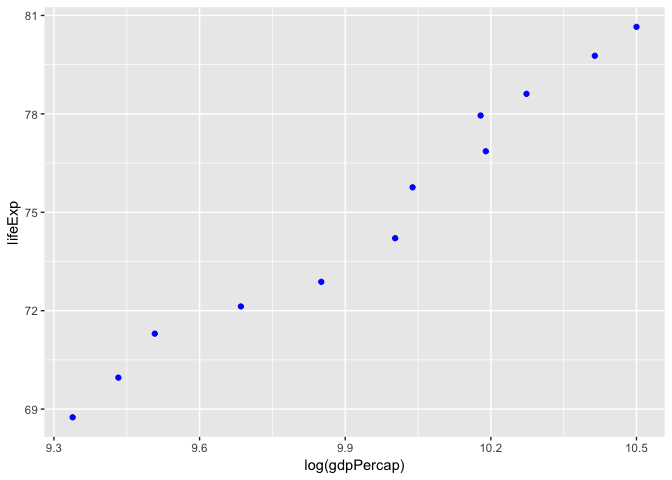

```r
gapminder %>%
  filter(country == "Canada") %>%
  ggplot(aes(log(gdpPercap), lifeExp)) + geom_point(colour="blue")
```

# Question 3

We will explore different plots. To do so, we will analyze the “trees” dataset from R. This dataset contains information from 31 black cherry trees, including their Girth, Height, and Volume.

We want to see if any of these variables are related. To do so, we will simply look at the scatterplots.

The first one will be a scatterplot of Girth vs. Volume, which clearly shows a nice linear trend.

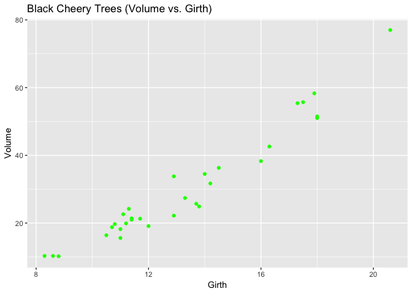

```r
trees %>%
  ggplot(aes(Girth, Volume)) +
  geom_point(colour="green") +
  ggtitle("Black Cheery Trees (Volume vs. Girth)")
```

There seems to be an upward trend for Volume and Girth.

For part 2, we wish to look at a different type of plot, rather than just scatterplots. Let’s look at an area plot (similar to histogram) of the distribution of heights of cherry trees.

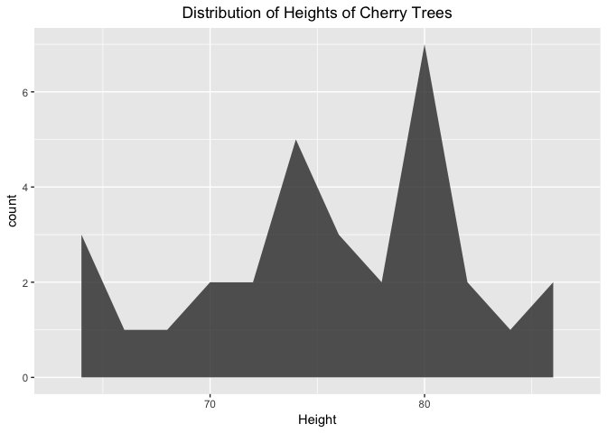

```r
trees %>%
  ggplot(aes(Height)) +
  geom_area(stat="bin", alpha=0.8, binwidth=2) +
  ggtitle("Distribution of Heights of Cherry Trees") +
  theme(plot.title = element_text(hjust = 0.5))
```

How about one more plot, just for fun?!

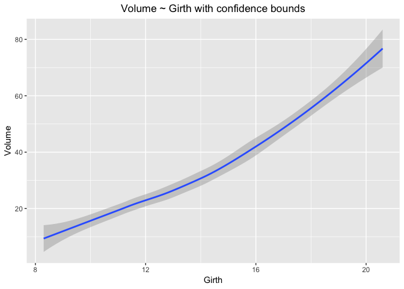

```r
trees %>%
  ggplot(aes(Girth, Volume)) +
  geom_smooth() +
  ggtitle("Volume ~ Girth with confidence bounds") +
  theme(plot.title = element_text(hjust = 0.5))
```

Above, we predicted Volume using Girth. Then produced a LOESS curve, with appropriate confidence bounds on the plot.

# Bonus Question 1

We are given the following code:

```r
filter(gapminder, country == c("Rwanda", "Afghanistan"))
```

```
## # A tibble: 12 x 6
##    country     continent  year lifeExp      pop gdpPercap
##    <fct>       <fct>     <int>   <dbl>    <int>     <dbl>
##  1 Afghanistan Asia       1957    30.3  9240934      821.
##  2 Afghanistan Asia       1967    34.0 11537966      836.
##  3 Afghanistan Asia       1977    38.4 14880372      786.
##  4 Afghanistan Asia       1987    40.8 13867957      852.
##  5 Afghanistan Asia       1997    41.8 22227415      635.
##  6 Afghanistan Asia       2007    43.8 31889923      975.
##  7 Rwanda      Africa     1952    40    2534927      493.
##  8 Rwanda      Africa     1962    43    3051242      597.
##  9 Rwanda      Africa     1972    44.6  3992121      591.
## 10 Rwanda      Africa     1982    46.2  5507565      882.
## 11 Rwanda      Africa     1992    23.6  7290203      737.
## 12 Rwanda      Africa     2002    43.4  7852401      786.
```

And when we run it, we only get a subset of the data from Rwanda and Afghanistan. In order to do this properly, there are 2 different ways which could work. Firstly, we could replace the “==” with “%in%”. This will produce the countries of either Rwanda or Afghanistan. Secondly, we could use the “|” operator. These 2 methods are demonstrated below.

```r
gapminder %>%
  filter(country %in% c("Rwanda", "Afghanistan"))
```

```
## # A tibble: 24 x 6
##    country     continent  year lifeExp      pop gdpPercap
##    <fct>       <fct>     <int>   <dbl>    <int>     <dbl>
##  1 Afghanistan Asia       1952    28.8  8425333      779.
##  2 Afghanistan Asia       1957    30.3  9240934      821.
##  3 Afghanistan Asia       1962    32.0 10267083      853.
##  4 Afghanistan Asia       1967    34.0 11537966      836.
##  5 Afghanistan Asia       1972    36.1 13079460      740.
##  6 Afghanistan Asia       1977    38.4 14880372      786.
##  7 Afghanistan Asia       1982    39.9 12881816      978.
##  8 Afghanistan Asia       1987    40.8 13867957      852.
##  9 Afghanistan Asia       1992    41.7 16317921      649.
## 10 Afghanistan Asia       1997    41.8 22227415      635.
## # … with 14 more rows
```

```r
gapminder %>%
  filter(country == "Rwanda" | country == "Afghanistan")
```

```
## # A tibble: 24 x 6
##    country     continent  year lifeExp      pop gdpPercap
##    <fct>       <fct>     <int>   <dbl>    <int>     <dbl>
##  1 Afghanistan Asia       1952    28.8  8425333      779.
##  2 Afghanistan Asia       1957    30.3  9240934      821.
##  3 Afghanistan Asia       1962    32.0 10267083      853.
##  4 Afghanistan Asia       1967    34.0 11537966      836.
##  5 Afghanistan Asia       1972    36.1 13079460      740.
##  6 Afghanistan Asia       1977    38.4 14880372      786.
##  7 Afghanistan Asia       1982    39.9 12881816      978.
##  8 Afghanistan Asia       1987    40.8 13867957      852.
##  9 Afghanistan Asia       1992    41.7 16317921      649.
## 10 Afghanistan Asia       1997    41.8 22227415      635.
## # … with 14 more rows
```

Either of these methods will produce the desired result.